# TP technique quantitative

2023-11-04

TAILLE DE L’ECHANTILLON

```r
N <- 100
N
```

```
## [1] 100
```

DETERMINATION DU NOMBRE DE CLASSE

```r
K <- round(1+3.3*log10(N))
K
```

```
## [1] 8
```

CREATION DU VECTEUR DES OBSERVATIONS

```r
tube <- c(1.94, 2.20, 2.33, 2.39, 2.45, 2.50, 2.54, 2.61, 2.66, 2.85)
tube <- c(tube, 1.96, 2.21, 2.33, 2.40, 2.46, 2.51, 2.54, 2.62, 2.68, 2.87)
tube <- c(tube, 2.07, 2.26, 2.34, 2.40, 2.47, 2.52, 2.55, 2.62, 2.68, 2.90)
tube <- c(tube, 2.09, 2.26, 2.34, 2.40, 2.47, 2.52, 2.55, 2.62, 2.68, 2.91)
tube <- c(tube, 2.09, 2.28, 2.35, 2.40, 2.48, 2.52, 2.56, 2.62, 2.71, 2.94)
tube <- c(tube, 2.12, 2.29, 2.36, 2.41, 2.49, 2.52, 2.56, 2.63, 2.73, 2.95)
tube <- c(tube, 2.13, 2.30, 2.37, 2.42, 2.49, 2.53, 2.57, 2.63, 2.75, 2.99)
tube <- c(tube, 2.14, 2.31, 2.38, 2.42, 2.49, 2.53, 2.57, 2.65, 2.76, 2.99)
tube <- c(tube, 2.19, 2.31, 2.38, 2.42, 2.49, 2.53, 2.59, 2.66, 2.77, 3.09)
tube <- c(tube, 2.19, 2.31, 2.38, 2.42, 2.50, 2.54, 2.59, 2.66, 2.78, 3.12)
tube
```

```
##   [1] 1.94 2.20 2.33 2.39 2.45 2.50 2.54 2.61 2.66 2.85 1.96 2.21 2.33 2.40 2.46
##  [16] 2.51 2.54 2.62 2.68 2.87 2.07 2.26 2.34 2.40 2.47 2.52 2.55 2.62 2.68 2.90
##  [31] 2.09 2.26 2.34 2.40 2.47 2.52 2.55 2.62 2.68 2.91 2.09 2.28 2.35 2.40 2.48
##  [46] 2.52 2.56 2.62 2.71 2.94 2.12 2.29 2.36 2.41 2.49 2.52 2.56 2.63 2.73 2.95
##  [61] 2.13 2.30 2.37 2.42 2.49 2.53 2.57 2.63 2.75 2.99 2.14 2.31 2.38 2.42 2.49
##  [76] 2.53 2.57 2.65 2.76 2.99 2.19 2.31 2.38 2.42 2.49 2.53 2.59 2.66 2.77 3.09
##  [91] 2.19 2.31 2.38 2.42 2.50 2.54 2.59 2.66 2.78 3.12
```

DETERMINATION DU NOMBRE D’ELEMENTS

```r
len.tube <- length(tube)
len.tube
```

```
## [1] 100
```

CALCUL MIN

```r
min.tube <- min(tube)
min.tube
```

```
## [1] 1.94
```

CALCUL MAX

```r
max.tube <- max(tube)
max.tube
```

```
## [1] 3.12
```

CALCUL DE LA MEDIANE (METHODE 1)

```r
median.tube <- median(tube)
median.tube
```

```
## [1] 2.5
```

CALCUL DE LA MEDIANE (METHODE 2)

```r
median.tube <- quantile(tube, probs = c(0.5))
median.tube
```

```
## 50%
## 2.5
```

CALCUL DES QUARTILES (METHODE 1)

```r
quartiles.tube <- quantile(tube, probs = c(0.25, 0.5, 0.75))
quartiles.tube
```

```
##    25%    50%    75%
## 2.3575 2.5000 2.6225
```

CALCUL DES QUARTILES (METHODE 2)

```r
quartiles.tube <- quantile(tube, probs = (1:3)/4)
quartiles.tube
```

```
##    25%    50%    75%
## 2.3575 2.5000 2.6225
```

CALCUL DES DECILES (METHODE 1)

```r
deciles.tube <- quantile(tube, probs = c(0.1, 0.2, 0.3, 0.4, 0.5, 0.6, 0.7, 0.8, 0.9))
deciles.tube
```

```
##   10%   20%   30%   40%   50%   60%   70%   80%   90%
## 2.199 2.326 2.387 2.438 2.500 2.540 2.596 2.660 2.787
```

CALCUL DES DECILES (METHODE 2)

```r
deciles.tube <- quantile(tube, probs = (1:9)/10)
deciles.tube
```

```
##   10%   20%   30%   40%   50%   60%   70%   80%   90%
## 2.199 2.326 2.387 2.438 2.500 2.540 2.596 2.660 2.787
```

CALCUL DES DECILES (METHODE 3)

```r
deciles.tube <- quantile(tube, probs = seq(1:9)/10)
deciles.tube
```

```
##   10%   20%   30%   40%   50%   60%   70%   80%   90%
## 2.199 2.326 2.387 2.438 2.500 2.540 2.596 2.660 2.787
```

CALCUL DE LA MOYENNE

```r
avg.tube <- mean(tube)
avg.tube
```

```
## [1] 2.5005
```

CALCUL DE LA VARIANCE

```r
var.tube <- var(tube)
var.tube
```

```
## [1] 0.05540682
```

CALCUL DE L’ECART-TYPE

```r
sd.tube <- sd(tube)
sd.tube
```

```
## [1] 0.2353865
```

CALCUL DE QUELQUES STATISTIQUES

```r
summary.tube <- summary(tube)
summary.tube
```

```
##    Min. 1st Qu.  Median    Mean 3rd Qu.    Max.
##   1.940   2.357   2.500   2.501   2.623   3.120
```

CALCUL DU PAS

```r
pas <- (max.tube - min.tube)/K
pas
```

```
## [1] 0.1475
```

DETERMINATION DES INTERVALES (METHODE 1)

```r
breaks <- min.tube + (0:K) * pas
breaks
```

```
## [1] 1.9400 2.0875 2.2350 2.3825 2.5300 2.6775 2.8250 2.9725 3.1200
```

```r
epsilon <- 0.0001
# On ajoute epsilon sur le dernier element de breaks pour regler le proble du dernier element du tube hors intervale
breaks[length(breaks)] <- breaks[length(breaks)] + epsilon
breaks
```

```
## [1] 1.9400 2.0875 2.2350 2.3825 2.5300 2.6775 2.8250 2.9725 3.1201
```

DETERMINATION DES INTERVALES (METHODE 2)

```r
breaks <- max.tube - (K:0) * pas
breaks
```

```
## [1] 1.9400 2.0875 2.2350 2.3825 2.5300 2.6775 2.8250 2.9725 3.1200
```

```r
epsilon <- 0.0001
# On ajoute epsilon sur le dernier element de breaks pour regler le proble du dernier element du tube hors intervale
breaks[length(breaks)] <- breaks[length(breaks)] + epsilon
breaks
```

```
## [1] 1.9400 2.0875 2.2350 2.3825 2.5300 2.6775 2.8250 2.9725 3.1201
```

TRANSFORMATION DE “TUBE” EN VARIABLE QUALITATIVE

```r
tube.qual <- cut(tube, breaks = breaks, right = F)
tube.qual
```

```
##   [1] [1.94,2.09) [2.09,2.23) [2.23,2.38) [2.38,2.53) [2.38,2.53) [2.38,2.53)
##   [7] [2.53,2.68) [2.53,2.68) [2.53,2.68) [2.83,2.97) [1.94,2.09) [2.09,2.23)
##  [13] [2.23,2.38) [2.38,2.53) [2.38,2.53) [2.38,2.53) [2.53,2.68) [2.53,2.68)
##  [19] [2.68,2.83) [2.83,2.97) [1.94,2.09) [2.23,2.38) [2.23,2.38) [2.38,2.53)
##  [25] [2.38,2.53) [2.38,2.53) [2.53,2.68) [2.53,2.68) [2.68,2.83) [2.83,2.97)
##  [31] [2.09,2.23) [2.23,2.38) [2.23,2.38) [2.38,2.53) [2.38,2.53) [2.38,2.53)
##  [37] [2.53,2.68) [2.53,2.68) [2.68,2.83) [2.83,2.97) [2.09,2.23) [2.23,2.38)
##  [43] [2.23,2.38) [2.38,2.53) [2.38,2.53) [2.38,2.53) [2.53,2.68) [2.53,2.68)
##  [49] [2.68,2.83) [2.83,2.97) [2.09,2.23) [2.23,2.38) [2.23,2.38) [2.38,2.53)
##  [55] [2.38,2.53) [2.38,2.53) [2.53,2.68) [2.53,2.68) [2.68,2.83) [2.83,2.97)
##  [61] [2.09,2.23) [2.23,2.38) [2.23,2.38) [2.38,2.53) [2.38,2.53) [2.38,2.53)
##  [67] [2.53,2.68) [2.53,2.68) [2.68,2.83) [2.97,3.12) [2.09,2.23) [2.23,2.38)
##  [73] [2.23,2.38) [2.38,2.53) [2.38,2.53) [2.38,2.53) [2.53,2.68) [2.53,2.68)
##  [79] [2.68,2.83) [2.97,3.12) [2.09,2.23) [2.23,2.38) [2.23,2.38) [2.38,2.53)
##  [85] [2.38,2.53) [2.38,2.53) [2.53,2.68) [2.53,2.68) [2.68,2.83) [2.97,3.12)
##  [91] [2.09,2.23) [2.23,2.38) [2.23,2.38) [2.38,2.53) [2.38,2.53) [2.53,2.68)
##  [97] [2.53,2.68) [2.53,2.68) [2.68,2.83) [2.97,3.12)
## 8 Levels: [1.94,2.09) [2.09,2.23) [2.23,2.38) [2.38,2.53) ... [2.97,3.12)
```

CONSTRUCTION DU TABLEAU DES FREQUENCES ABSOLUES

```r
tube.eff <- table(tube.qual)
tube.eff
```

```
## tube.qual
## [1.94,2.09) [2.09,2.23) [2.23,2.38) [2.38,2.53) [2.53,2.68) [2.68,2.83)
##           3           9          18          29          22           9
## [2.83,2.97) [2.97,3.12)
##           6           4
```

CONSTRUCTION DU DIAGRAMME EN TUYAU D’ORGUE (METHODE 1)

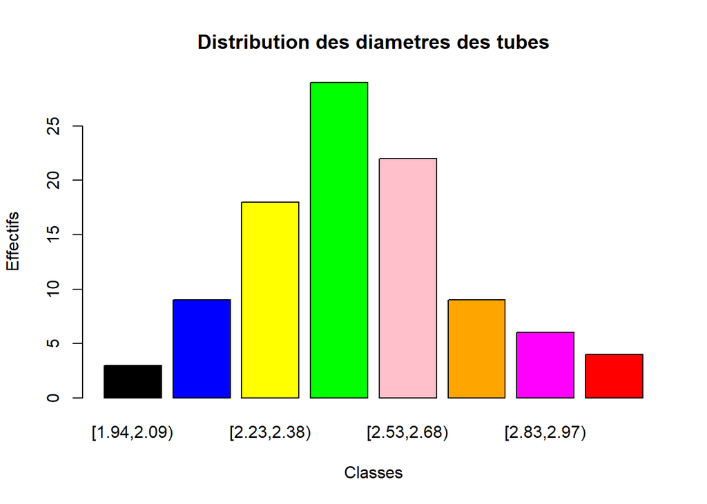

```r
main <- "Distribution des diametres des tubes"
# Etiquette de l'axe des abscisses
xlab <- "Classes"
# Etiquette de l'axe des ordonnees
ylab <- "Effectifs"
col <- c("black", "blue", "yellow", "green", "pink", "orange", "magenta", "red")
barplot(tube.eff, main = main, xlab = xlab, ylab = ylab, col = col)
```

CONSTRUCTION DU DIAGRAMME EN TUYAU D’ORGUE (METHODE 2)

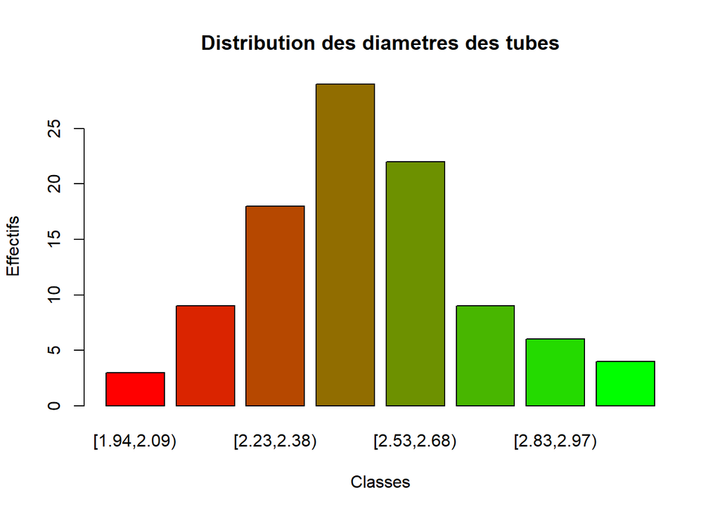

```r
main <- "Distribution des diametres des tubes"
# Etiquette de l'axe des abscisses
xlab <- "Classes"
# Etiquette de l'axe des ordonnees
ylab <- "Effectifs"
col <- colorRampPalette(c("red", "green"))
barplot(tube.eff, main = main, xlab = xlab, ylab = ylab, col = col(K))
```

CONSTRUCTION DU CAMENBERTS (METHODE 1)

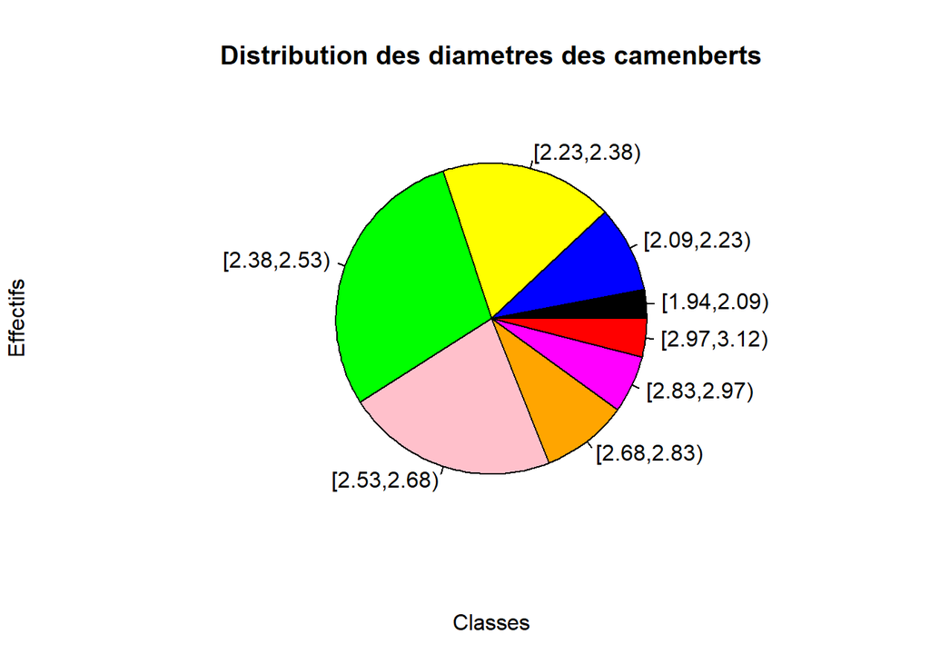

```r
main <- "Distribution des diametres des camenberts"
# Etiquette de l'axe des abscisses
xlab <- "Classes"
# Etiquette de l'axe des ordonnees
ylab <- "Effectifs"
col <- c("black", "blue", "yellow", "green", "pink", "orange", "magenta", "red")
pie(tube.eff, main = main, xlab = xlab, ylab = ylab, col = col)
```

CONSTRUCTION DU CAMENBERTSE (METHODE 2)

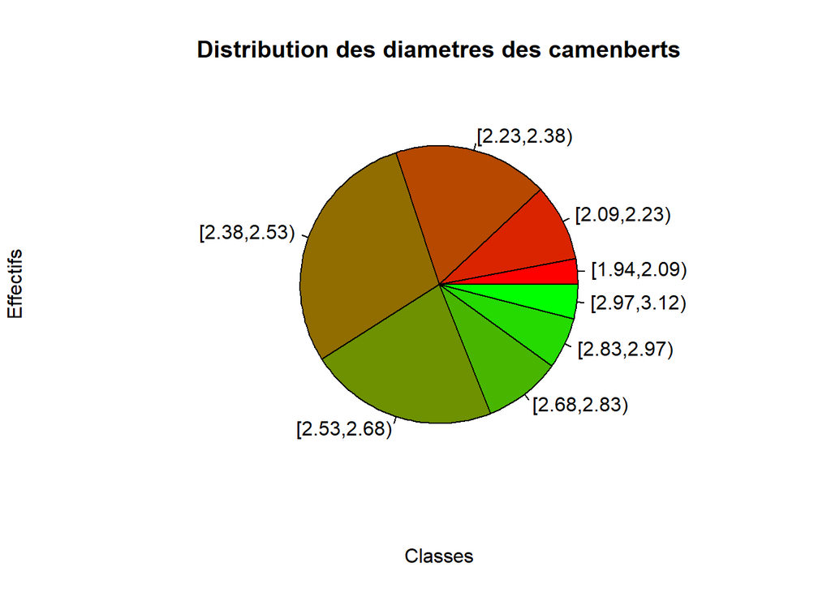

```r
main <- "Distribution des diametres des camenberts"
# Etiquette de l'axe des abscisses
xlab <- "Classes"
# Etiquette de l'axe des ordonnees
ylab <- "Effectifs"
col <- colorRampPalette(c("red", "green"))
pie(tube.eff, main = main, xlab = xlab, ylab = ylab, col = col(K))
```

CONSTRUCTION DU CAMENBERTS 3D (METHODE 1)

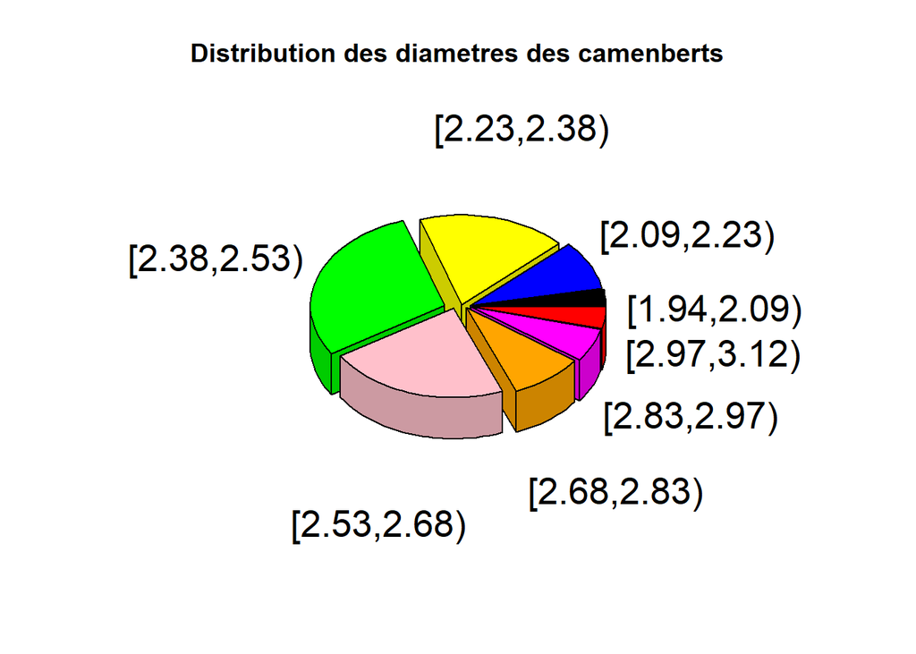

```r
library("plotrix")
col <- c("black", "blue", "yellow", "green", "pink", "orange", "magenta", "red")
pie3D(tube.eff, explode = 0.07, radius = 0.65, theta = 1.05, labelcex = 1.7,
      labelcol = "black", col = col, cex = 1.5, labels = levels(tube.qual), main = main)
```

CONSTRUCTION DU CAMENBERTS 3D (METHODE 2)

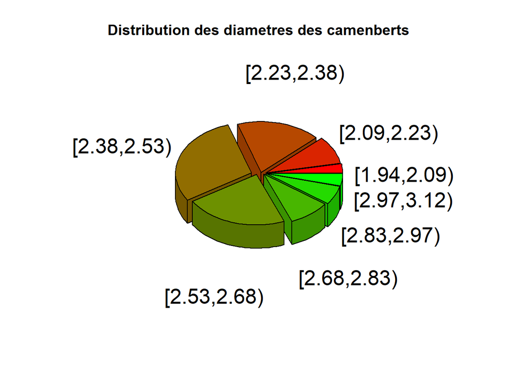

```r
library("plotrix")
col <- colorRampPalette(c("red", "green"))
pie3D(tube.eff, explode = 0.07, radius = 0.65, theta = 1.05, labelcex = 1.7,
      labelcol = "black", col = col(K), cex = 1.5, labels = levels(tube.qual), main = main)
```

CONSTRUCTION DU BLOXPLOT

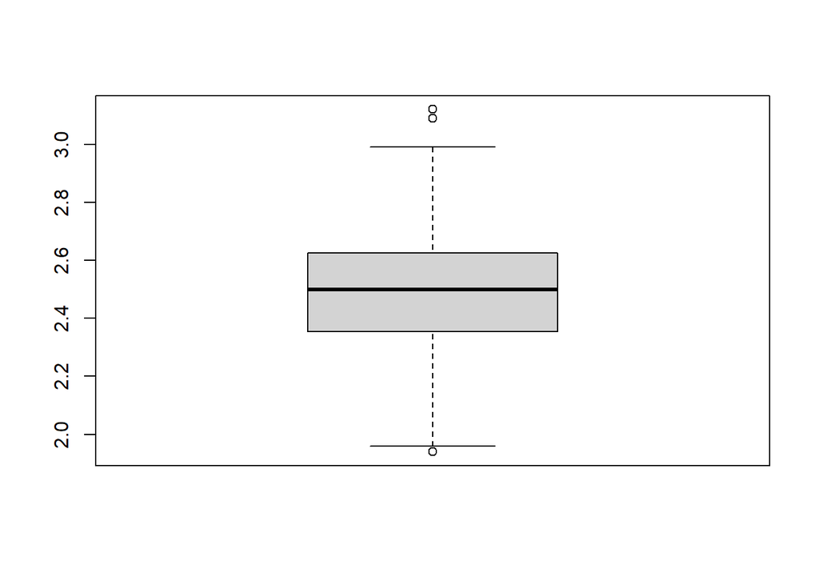

```r
boxplot(tube)
```

PROPORTION DES TUBES DONT LE DIAMETRE EST INFERIEUR A 2.58

```r
round(mean(tube < 2.58) * 100, 2)
```

```
## [1] 68
```

CHARGEMENT DES DONNEES (METHODE 1)

```r
path.folder <- "C:\\Users\\HP\\Documents\\Cours B3\\TECHNIQUES QUANTITATIVES"
setwd(path.folder)
data <- read.csv2("DATA.csv")
```

CHARGEMENT DES DONNEES (METHODE 2)

```r
file.name <- "C:\\Users\\HP\\Documents\\Cours B3\\TECHNIQUES QUANTITATIVES\\DATA.csv"
data <- read.csv2(file.name)
```

AFFICHER LES 5 PREMIERES LIGNES DU JEU DE DONNEES “DATA”

```r
head(data, 5)
```

|  | X | bgi | tenure | region | aspu | refill_amt | nb_refill | refill_mode | frequent_user |
| --- | --- | --- | --- | --- | --- | --- | --- | --- | --- |
| 1 | 3205907 | 0 | 806 | 2 | 131 | 150 | 0.5 | 300.0000 | 0 |
| 2 | 918451 | 0 | 367 | 5 | 809 | 830 | 3.7 | 224.3243 | 1 |
| 3 | 2153106 | 0 | 2572 | 4 | 648 | 660 | 1.6 | 412.5000 | 0 |
| 4 | 2961853 | 0 | 2312 | 3 | 435 | 425 | 2.1 | 202.3810 | 1 |
| 5 | 3306416 | 0 | 437 | 2 | 4337 | 4085 | 12.4 | 329.4355 | 0 |

AFFICHER LES 5 DERNIERES LIGNES DU JEU DE DONNEES “DATA”

```r
tail(data, 5)
```

|  | X | bgi | tenure | region | aspu | refill_amt | nb_refill | refill_mode | frequent_user |
| --- | --- | --- | --- | --- | --- | --- | --- | --- | --- |
| 199996 | 1022158 | 1 | 952 | 5 | 2198 | 1543 | 7.7 | 200.3896 | 1 |
| 199997 | 697871 | 1 | 230 | 5 | 5279 | 5115 | 10.9 | 469.2661 | 1 |
| 199998 | 1276954 | 1 | 2379 | 5 | 35715 | 2000 | 7.1 | 281.6901 | 1 |
| 199999 | 1973604 | 1 | 298 | 4 | 3858 | 3565 | 4.3 | 829.0698 | 1 |
| 200000 | 3098438 | 1 | 2775 | 4 | 19515 | 19345 | 7.8 | 2480.1282 | 1 |

SUPPRIMER LA 1ERE COLONNE (X)

```r
data <- data[, -c(1)]
```

AFFICHER LA STRUCTURE DU DATASET “data”

```r
str(data)
```

```
## 'data.frame':    200000 obs. of  8 variables:
##  $ bgi          : int  0 0 0 0 0 0 0 0 0 0 ...
##  $ tenure       : int  806 367 2572 2312 437 1884 5690 514 4107 587 ...
##  $ region       : int  2 5 4 3 2 5 4 3 5 4 ...
##  $ aspu         : int  131 809 648 435 4337 1370 195 284 335 114 ...
##  $ refill_amt   : int  150 830 660 425 4085 1540 210 310 335 100 ...
##  $ nb_refill    : num  0.5 3.7 1.6 2.1 12.4 4.9 0.6 1.7 2.1 0.5 ...
##  $ refill_mode  : num  300 224 412 202 329 ...
##  $ frequent_user: int  0 1 0 1 0 1 0 1 1 0 ...
```

AFFICHER LA DIMMENSION DU DATASET “data”

```r
dim(data)
```

```
## [1] 200000      8
```

AFFICHER LE NOMBRE DE LIGNES

```r
nrow(data)
```

```
## [1] 200000
```

AFFICHER LE NOMBRE DE COLONNE

```r
ncol(data)
```

```
## [1] 8
```

AFFICHER LES NOMS DES COLONNES

```r
colnames(data)
```

```
## [1] "bgi"           "tenure"        "region"        "aspu"
## [5] "refill_amt"    "nb_refill"     "refill_mode"   "frequent_user"
```

TABLEAU DES EFFECTIF DE LA VARIABLE “bgi” (METHODE 1)

```r
tab.bgi <- table(data[, "bgi"])
tab.bgi
```

```
##
##      0      1
##  15440 184560
```

TABLEAU DES EFFECTIF DE LA VARIABLE “bgi” EN CHANGEANT LES NOMS DES VALEURS (METHODE 1)

```r
tab.bgi <- table(data[, "bgi"])
names(tab.bgi) <- c("bad", "good")
tab.bgi
```

```
##    bad   good
##  15440 184560
```

TABLEAU DES EFFECTIF DE LA VARIABLE “bgi” (METHODE 2)

```r
tab.bgi <- table(data$bgi)
tab.bgi
```

```
##
##      0      1
##  15440 184560
```

TABLEAU DES EFFECTIF DE LA VARIABLE “bgi” EN CHANGEANT LES NOMS DES VALEURS (METHODE 1)

```r
tab.bgi <- table(data$bgi)
names(tab.bgi) <- c("bad", "good")
tab.bgi
```

```
##    bad   good
##  15440 184560
```

CONSTRUCTION DU CAMENBERTS 3D (METHODE 1)

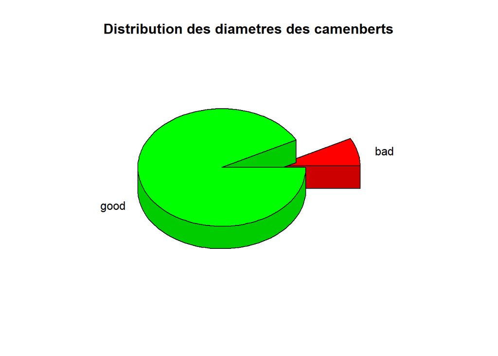

```r
library("plotrix")
col <- c("red", "green")
pie3D(tab.bgi, explode = 0.25, radius = 0.75, theta = 1.1, labelcex = 1,
      labelcol = "black", col = col, lwd = 2, labels = names(tab.bgi), main = main)
```